# A Git workflow with RStudio, R and `usethis`

In this guide, we will work on a cook book project using Git, R and RStudio. We will start going through all the steps for an individual project (you’re working on the cook book alone) and then we will see how to collaborate with others.

# Preparations

To follow this guide you need:

- Git installed
- RStudio and R installed
- The R package `usethis` installed

The [`usethis`](https://usethis.r-lib.org/) is a very cool workflow package that has a lot of functionality including Git workflows. Install it in R with:

```r
install.packages("usethis")
```

## Setup PAT to use HTTPS protocol with GitHub

You can manage access to GitHub with a personal access token (PAT) instead of using your password. Check if you already have a personal access token with the correct configurations for GitHub.

```r
usethis::gh_token_help()
```

This will tell you exactly what’s going on (in general, `usethis` is very helpful - so always read what it prints in the console): Do you already have a token or are problems with your current token? And if you need a token, it will also tell you how you can create one. To create a new token, call the function:

```r
usethis::create_github_token()
```

This will open GitHub and ask you to sign in.

Next, you are asked to create a new personal access token.

On top enter a note to remind you what this token is for (e.g. Something like “RStudio on PC”).

Set an expiration date of your choice (the shorter the more secure, but you have to update more often - GitHub will send you a reminder for this).

You can also choose the scope for your PAT but for general use, the default settings are fine.

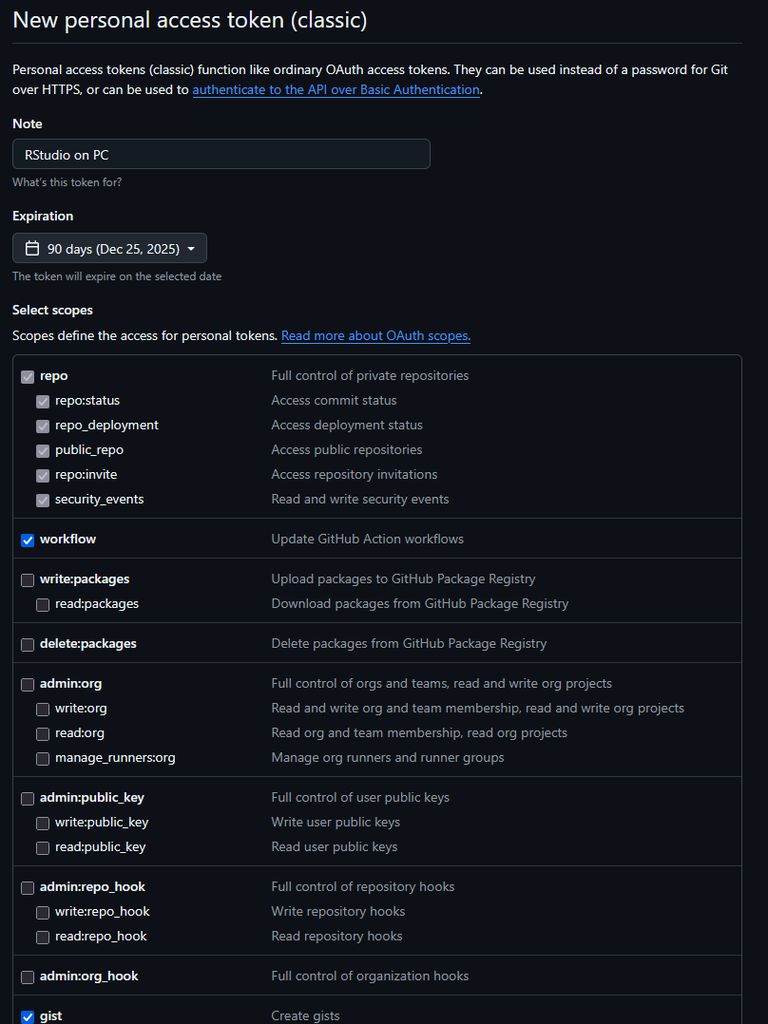

Scroll down and click on **Generate token**.

Copy the token to the clipboard.

**Warning**

You will not be able to read the token again after you closed GitHub. So leave the window open until you successfully set up your connection. You can also save the token in a safe place (e.g. a password manager).

Now register the token with git using the function:

```r
gitcreds::gitcreds_set()
```

You are now prompted to paste your token into the R console.

Now your PAT should be added to the credentials. You can check it again with

```r
usethis::gh_token_help()
```

Check the console to see if everything is fine and `usethis` now knows your GitHub Account data.

### Optional: Add `usethis` to your `.Rprofile`

If you want to load the `usethis` package automatically when starting R, you can add it to your `.Rprofile`. This way, you have all the `usethis` functionality available without having to load the package first.

**WarningCareful when adding packages to `.Rprofile`**

Loading packages via the `.Rprofile` should only be done for packages that are not used in your R scripts. Otherwise, you might forget to explicitly load the package in your script and the script breaks if you use it somewhere else.

Adding utility packages like `usethis` to the `.Rprofile` can however be very convenient.

Read more about this topic [here](https://rstats.wtf/r-startup.html#rprofile).

You can open your `.Rprofile` file with

```r
usethis::edit_r_profile()
```

Then you can add the following line, save the file and close it:

```r
# suppress messages just means that messages are not printed when loading the package
if (interactive()) {
  suppressMessages(library(usethis))
}
options(
  usethis.protocol = "https" # or "ssh" if you set up ssh
)
```

With this, `usethis` will be loaded every time you open RStudio and you already registered the default protocol that you want to use with Git (This is only relevant for the Git things you do with `usethis`).

# A Git workflow for your individual project

## Step 1: Create new R project

To create a new R project for this exercise call the function:

```r
usethis::create_project(path = "path/to/project/project_name")
```

This will create a folder with `project_name` and set up an empty RStudio project. The project will open in a new RStudio instance. You can see that by default, the project already has some files inside (among them a `.gitignore` file).

Here you can see my new project (called “demo_project”) in R Studio. The files are highlighted in pink:

[figure not shown]

Of course you can also set up the project manually via RStudio (File -> New Project -> New Directory -> New Project) but I want to showcase the functionality of `usethis` here.

## Step 2: Initialize a new Git repository

With the project open call the function

```r
usethis::use_git()
```

Read the text in the console:

R tells you which changes will be committed. This is just the first commit that will include all the files that are created by default and that are not in the `.gitignore`.

Confirm that you want to commit these files by selecting the correct number for the “Yes” answer and press enter. Then agree to the first commit with the commit message “Initial commit” (again by selecting the correct number).

RStudio will restart and the Git GUI client will be added.

Can you find the `Git` tab in the top right pane? Here is where all the buttons for Git are located.

[figure not shown]

## Step 3: Publish your project on GitHub

You can skip this step if you only want to work locally. But I recommend you try it, it’s really cool.

To create a new GitHub repository and link it to your local repository, all we need to do is call the function:

```r
usethis::use_github(private = TRUE) # default is private = FALSE
```

With the `private` argument you can choose if your repository should be private or public.

This should now open GitHub in the browser and bring you to a freshly created GitHub project with all the files that were in your local repository (not a lot yet).

Really convenient 🎉

## Step 4: Make some changes

Now let’s make some changes to the project.

Create a new R file in your project and add some content to it.

You can just copy the following code for convenience:

```r
library(ggplot2)
penguins |>
  ggplot(aes(x = flipper_len, y = body_mass, color = species)) +
  geom_point() +
  theme_minimal()
```

Save the file in your project.

## Step 5: Make a commit

To commit this file, just click on the “Commit” button in the Git pane:

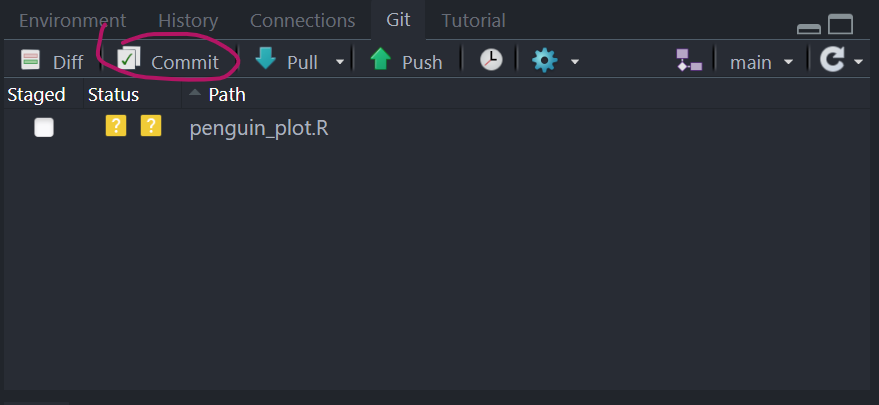

Now you can select which files you want to commit. In this case we only have one file. To select (i.e. stage) files, just check the check box next to the file name. Now you can also see the changes that you made in the file (the code that you added is green, deleted code is shown in red).

[figure not shown]

When everything is finished, close the commit window that opened.

## Step 6: Push the changes to GitHub

Now push the changes to GitHub by clicking on the green upward arrow on the top right.

[figure not shown]

Go to GitHub and check if everything was pushed as you expected.

# Collaboration workflows

In collaboration workflows, you normally first need to be added as a collaborator to a project. Then you can clone the project to your computer and work on it. We will skip those two steps here. If you want to try it, the GitHub Desktop guide shows how to add collaborators on GitHub. To clone a repository from RStudio, go to **File -> New Project -> Version Control -> Git** and paste the repository URL. Or use `usethis`:

```r
usethis::create_from_github("owner/repo") # e.g. "selinaZitrone/cookBook"
```

In the following, we will explore branching and merging from inside RStudio on our own project. But the workflow is the same when you work on a project of someone else.

## Step 1: Create a new branch

In this step, you will create a new branch for a new feature that you want to introduce. This branch will later be used to do a pull request on GitHub.

In RStudio, you can create a new branch (e.g. to add a data analysis file), by clicking on the little violet branch symbol in the Git pane:

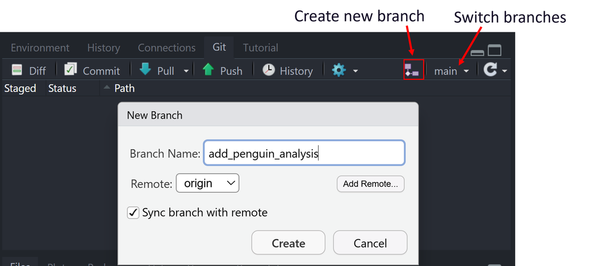

## Step 2: Change files and push changes

Now that you are on your new branch, you can make changes to the files.

You could for example add a new R file with some data analysis code. Or you could add new code to the R file that you already created in step 4 of the individual workflow.

When you are done making changes, commit and push them (like in step 5 and 6 of the individual workflow).

Now your changes should be available on GitHub in the new branch and you can do a pull request.